# week05-day02HWNachoDeVicente

| backpack_weight | body_weight | ratio | back_problems | major | year | sex | status | units |
| --- | --- | --- | --- | --- | --- | --- | --- | --- |
| 9 | 125 | 0.0720000 | 1 | Bio | 3 | Female | U | 13 |
| 8 | 195 | 0.0410256 | 0 | Philosophy | 5 | Male | U | 12 |
| 10 | 120 | 0.0833333 | 1 | GRC | 4 | Female | U | 14 |
| 6 | 155 | 0.0387097 | 0 | CSC | 6 | Male | G | 0 |
| 8 | 180 | 0.0444444 | 0 | EE | 2 | Female | U | 14 |
| 5 | 240 | 0.0208333 | 0 | History | 0 | Male | G | 0 |
| 8 | 170 | 0.0470588 | 0 | CM | 3 | Male | U | 15 |
| 4 | 185 | 0.0216216 | 1 | ARCE | 5 | Female | U | 18 |
| 5 | 130 | 0.0384615 | 0 | Bio | 4 | Female | U | 14 |
| 2 | 120 | 0.0166667 | 0 | Bio | 5 | Female | U | 8 |

[output cut: 90 more lines]

Question 1.

Load in the libraries you need, and look at the backpack data. Take note of variable names and dimensions.

Question 2.

What is the distribution of backpack weights that students are carrying? Choose an appropriate graph to show the distribution.

Backpacks weigth distribution by major

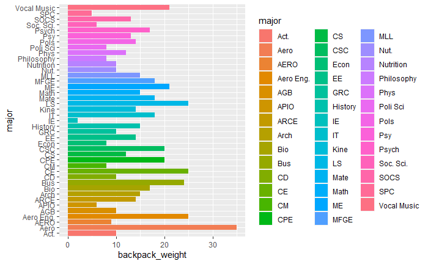

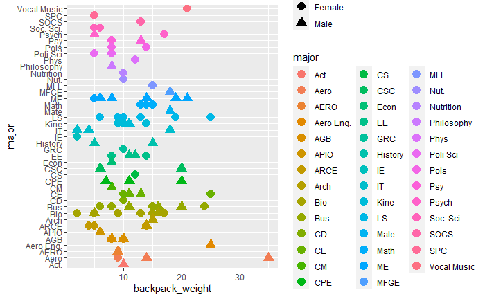

This dsitribution is by major and sex

Question 3.

Are there differences in backpack weight between sex?

```r
backpack %>%
  ggplot(aes(x = sex , y = backpack_weight), stat = 'identity')+
  geom_col(fill = 'light blue')
```

[output not shown]

Question 4.

What is the relationship between body weight and backpack weight?

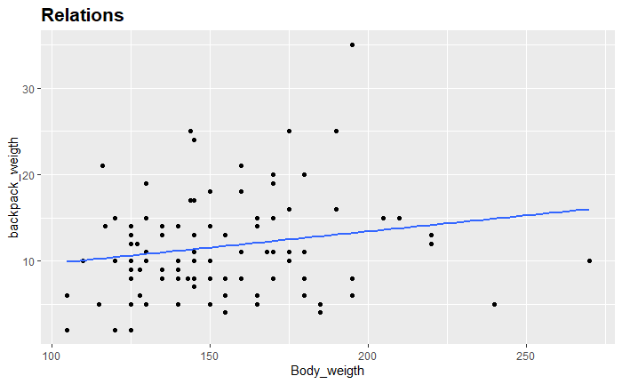

Question 5.

Is this relationship different between men and women? Choose an appropriate plot and interpret your findings.

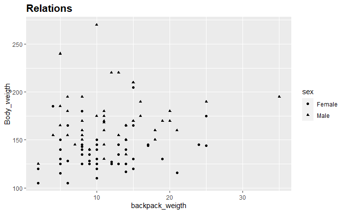

```r
backpack %>%
  ggplot(aes(x= body_weight , y = backpack_weight)) +
  labs(x = 'Body_weigth', y = 'backpack_weigth',title= 'Relations')+
  theme(plot.title = element_text(size = 16,face = "bold")) +
  geom_point(aes(shape = sex,show.legend = FALSE))+
  #geom_smooth(method = "lm", se = FALSE)+
  coord_flip()
```

The table shows that the data is concentrate and no a clear relation as heavy the person/ sex more weigth can carry

Question 6. What proportion of students report back pain?

```r
group_by(Body)
count()
```

[output not shown]

Question 7.

Is this proportion different between men and women?

Question 8.

Now you’ve investigated your data separately, create plots to describe the relationship between backpack weight, body weight, gender and reported backpain.

Try both backpack_weight and body_weight as well as the ratio.

Hint: faceting would be useful here.